# **Final: MAT2021**

December 6, 2024

## Instructions

- Students must use R or R Studio in **full-screen mode**.
- Using Internet browsers is **not** allowed. Only accessing the course website [(https://learning.hanyang.ac.kr)](https://learning.hanyang.ac.kr) for uploading the final answers is allowed.
- To prevent academic dishonesty, students **cannot** leave before the exam ends.
- Late submissions within 10 minutes past the deadline will incur a 5-point deduction, and submissions more than 10 minutes late will receive 0 points.
- We will give you 0 points if over a hundred lines of your code are perfectly identical to other students.
- If you do not follow these rules, we will give you 0 points for this exam.
- In this exam, an F grade will be given if you use ChatGPT, KakaoTalk, etc.
- Students should write (a single) R code about answers of excercises, submit it on course website [(https://learning.hanyang.ac.kr)](https://learning.hanyang.ac.kr).
  - [for 11295 (Fri 10:30~12:00)](https://learning.hanyang.ac.kr/courses/160878)
  - [for 12984 (Fri 13:00~14:30)](https://learning.hanyang.ac.kr/courses/160879)
- If you have any questions, please raise your hand.
- Before leaving the classroom, please **check** whether your answers are uploaded well.
- Students **must return** their exam papers after the test is finished.

Student Number

Name

## Simulation

**1**. (4pts) A $\chi^2$ random variable on $n$ degrees of freedom has the same distribution as the sum of $n$ independent the square of standard random variables. Generate 1000 simulations of a $\chi^2$ random variable on 8 degrees of freedom, and estimate its mean and variance.

**(2-5)**. Let $f(x) = (\sin x)^2$ for $0 < x < 2\pi$.

**2**. (2pts) Use `curve()` function to draw $f(x)$. Set `xlim=c(0,2*pi)` and use `col="green"`.

**3**. (2pts) Use Monte Carlo integration with 10000 simulation samples to find the area under $f(x)$ on the range $0 < x < 2\pi$.

**4**. (10pts) Write a function called `rsin2`, which generates random values from the density $f(x)/k$, $0 < x < 2\pi$, where $k$ is the area found above (in Problem **3**). The function should take arguments specifying how many samples are required, e.g., `rsin2(10)` would return a vector of 10 samples from this distribution. Use the rejection method to draw the samples. It can be realized as follows:

1. Draw `X ~ f(X)`, `U ~ unif(0,1)`, where $X$ is also a uniform random variable with range $(0, 2\pi)$.
2. We accept only those `X` for which $U f(X) < \frac{1}{2.01} g(X)$. To calculate `f(X)` and `g(X)`, you can use `dunif(X, max=2*pi)` and $\frac{\sin(X)^2}{k}$, respectively.

**5**. (2pts) Plot a histogram based on 10000 samples from `rsin2` function. Use `xlab="x"` and `probability=TRUE` options.

```r
#1
nsim <- 1000
n <- 8
res <- c()
for(i in 1:nsim){
  res <- c(res, sum(rnorm(n)^2))
}
mean(res)
```

```
## [1] 8.100825
```

```r
var(res)
```

```
## [1] 17.26037
```

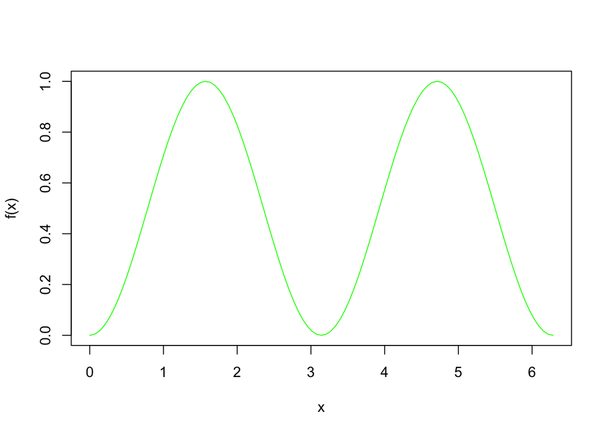

```r
#2
f <- function(x) return(((sin(x))^2))
curve(f, xlim=c(0,2*pi), col="green")
```

```r
#TRUE
#install.packages("rmutil")
library(rmutil)
int(f, a=0, b=2*pi)
```

```
## [1] 3.141593
```

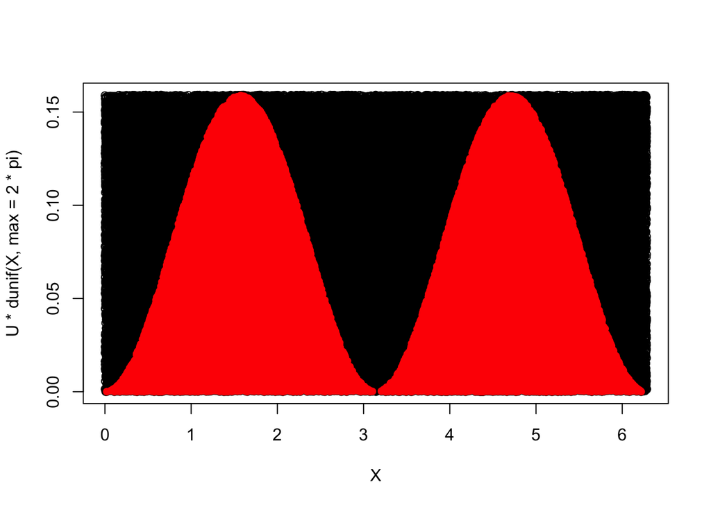

```r
#3
n <- 10000
u <- runif(n,0,2*pi)
k <- mean(f(u))*2*pi

#4
rsin2 <- function(n) {
  result_vec <- c()
  f <- function(x) return(((sin(x))^2))
  while(TRUE){
    weight <- 10
    U <- runif(n*weight)
    X <- runif(n*weight, max=2*pi)
    plot(X, U*dunif(X, max=2*pi))
    points(X[U*dunif(X, max=2*pi) < (1/2.01)*(sin(X)^2)/k], (U*dunif(X, max=2*pi))[U*dunif(X, max=2*pi) < (1/2.01)*(sin(X)^2)/k], pch=16,col="red")
    X <- X[(U*dunif(X, max=2*pi)) < ((1/2.02)*(sin(X)^2)/k)]

    if(length(X)>n){
      result_vec <- X[c(1:n)]
      break
    }else{
      weight <- weight*2
    }
  }
  return(result_vec)
}

#5
fnew <- function(x) return(((sin(x))^2)/k)

hist(rsin2(10000), xlab="x", probability = T, ylim=c(0, 1/k), breaks = 100, xlim=c(0,2*pi))
```

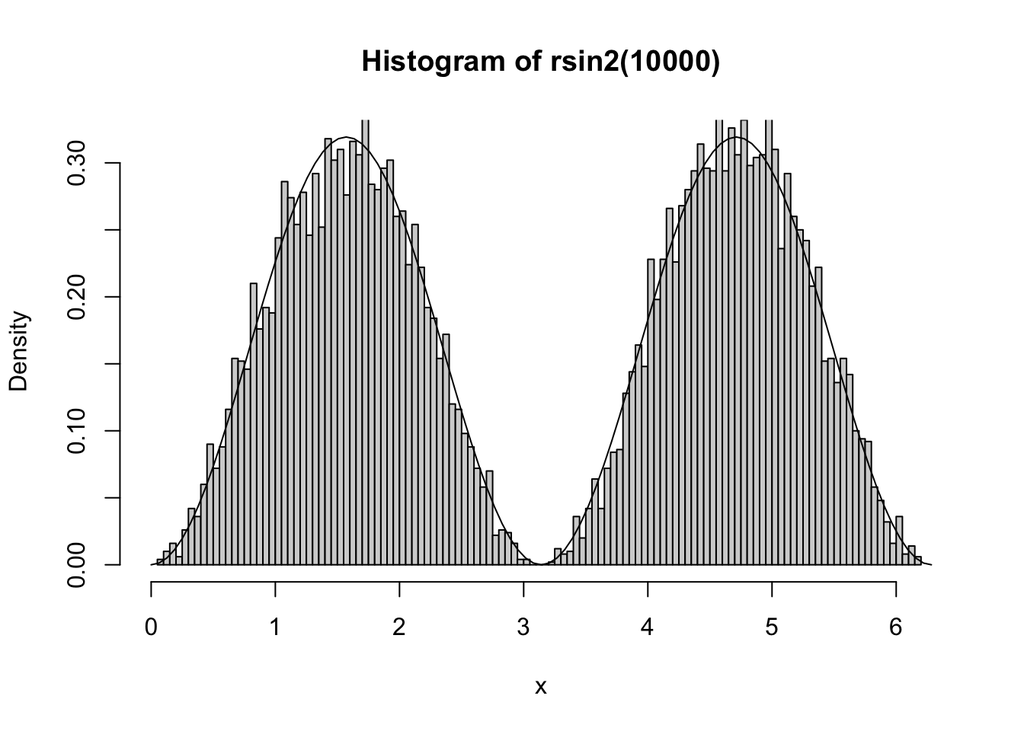

```r
curve(fnew, add=TRUE)
```

## Computational linear algebra

**6**. (5pts) Use `svd()` function to find a square root of the $4\times 4$ symmetric Hilbert matrix $H$. Note that a matrix $B$ is said to be a square root of $H$ if $BB=H$.
$$H=
\begin{bmatrix}
1 & \frac{1}{2} & \frac{1}{3} & \frac{1}{4}\\
\frac{1}{2} & \frac{1}{3} & \frac{1}{4} & \frac{1}{5}\\
\frac{1}{3} & \frac{1}{4} & \frac{1}{5} & \frac{1}{6}\\
\frac{1}{4} & \frac{1}{5} & \frac{1}{6} & \frac{1}{7}
\end{bmatrix}$$

**7**. (5pts) Use `qr()`, `qr.Q()`, `qr.R()`, and `backsolve()` functions to find the point $x$ in two dimensions which minimizes the distance between $y=\begin{bmatrix} 7 & 3 & 5 & 4 & 8\end{bmatrix}^T$ and $Ax$ where
$$A =
\begin{bmatrix}
1 & 2\\
1 & 3\\
1 & 4\\
1 & 5\\
1 & 6
\end{bmatrix}.$$

**8**. (10pts) Use `for()`, `if()`, and `while()` functions to write the matrix $G$
$$G =
\begin{bmatrix}
2 & -1 & -2\\
-4 & 6 & 3\\
-4 & -2 & 8
\end{bmatrix}$$
as a product of two matrices $L$ (lower triangular matrix with unit values on the diagonal) and $U$ (upper triangular). Do **not** use pre-defined LU decomposition functions in R.

```r
#6
H4 <- matrix(c(1,1/2,1/3,1/4,1/2,1/3,1/4,1/5,1/3,1/4,1/5,1/6,1/4,1/5,1/6,1/7), ncol=4)
H4.svd <- svd(H4)
B <- (H4.svd$u %*% diag(sqrt(H4.svd$d)) %*% t(H4.svd$u))
B
```

```
##           [,1]      [,2]      [,3]      [,4]
## [1,] 0.9114604 0.3390312 0.1927197 0.1309843
## [2,] 0.3390312 0.3528552 0.2474522 0.1806979
## [3,] 0.1927197 0.2474522 0.2411021 0.2085577
## [4,] 0.1309843 0.1806979 0.2085577 0.2226032
```

```r
#check 1
#(H4.svd$u %*% diag(sqrt(H4.svd$d)) %*% t(H4.svd$u))%*%(H4.svd$u %*% diag(sqrt(H4.svd$d)) %*% t(H4.svd$u))
#check 2
library(expm)
sqrtm(H4)
```

```
##           [,1]      [,2]      [,3]      [,4]
## [1,] 0.9114604 0.3390312 0.1927197 0.1309843
## [2,] 0.3390312 0.3528552 0.2474522 0.1806979
## [3,] 0.1927197 0.2474522 0.2411021 0.2085577
## [4,] 0.1309843 0.1806979 0.2085577 0.2226032
```

```r
#7
y <- c(7,3,5,4,8)
A <- matrix(c(1,1,1,1,1,2,3,4,5,6), ncol=2)
A.QR <- qr(A)
Q <- qr.Q(A.QR, complete = TRUE)
R <- qr.R(A.QR, complete = TRUE)
Qty <- crossprod(Q, y)
beta_hat_ols <- backsolve(R, Qty)
beta_hat_ols
```

```
##      [,1]
## [1,]  4.2
## [2,]  0.3
```

```r
#check
qr.solve(A,y)
```

```
## [1] 4.2 0.3
```

```r
#8
G <- matrix(c(2,-4,-4,-1,6,-2,-2,3,8), nrow=3)
n <- nrow(G); L <- diag(3); U <- matrix(0, nrow=3, ncol=3)
for(j in 1:3){
  for(i in 1:3){
    if(j>=i){
      #update U
      k <- i-1
      subtr <-0
      while(k>0){
        subtr <- subtr + L[i,k]*U[k,j]
        k <- k-1
      }
      U[i,j] <- G[i,j] - subtr
    }else{
      #update L
      l <- j-1
      subtr <- 0
      while(l>0){
        subtr <- subtr + L[i,l]*U[l,j]
        l <- l-1
      }
      L[i,j] <- (G[i,j]-subtr)/U[j,j]
    }
  }
}
L
```

```
##      [,1] [,2] [,3]
## [1,]    1    0    0
## [2,]   -2    1    0
## [3,]   -2   -1    1
```

```r
U
```

```
##      [,1] [,2] [,3]
## [1,]    2   -1   -2
## [2,]    0    4   -1
## [3,]    0    0    3
```

```r
#check
library(matrixcalc)
lu.decomposition(G)
```

```
## $L
##      [,1] [,2] [,3]
## [1,]    1    0    0
## [2,]   -2    1    0
## [3,]   -2   -1    1
##
## $U
##      [,1] [,2] [,3]
## [1,]    2   -1   -2
## [2,]    0    4   -1
## [3,]    0    0    3
```

## Sorting

**9**. (20pts) Consider an example vector $\mathbf{x}$:

```r
x <- c(9, -3, 5, 2, 6, 8, -6, 1, 3); x
```

```
## [1]  9 -3  5  2  6  8 -6  1  3
```

A person suggested a new sorting algorithm not in the textbook.

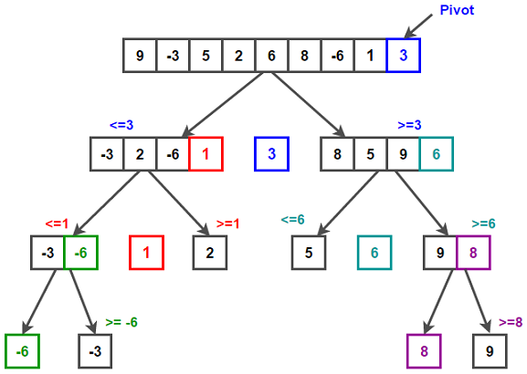

Write an R function `yoursort`, based on their algorithm, described in the following flowchart.

Your `yoursort` function **should** match the flowchart in the following picture. Assume that input `x` is always a length-$n$ `numeric` vector only containing different real numbers or `NA`.

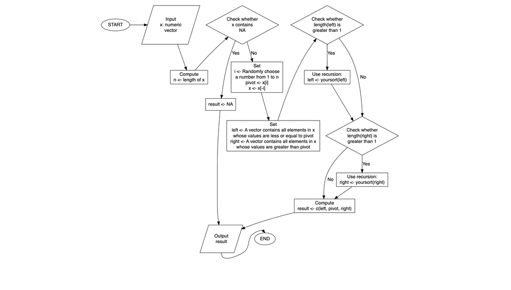

```r
#9
yoursort <- function(x) {
  if(any(is.na(x))){
    result <- NA
  }else{
    n <- length(x)
    i <- sample(1:n, 1)
    pivot <- x[i]
    x <- x[-i]

    left <- x[which(x <= pivot)]
    right <- x[which(x > pivot)]

    # recursion
    if (length(left) > 1) left <- yoursort(left)
    if (length(right) > 1) right <- yoursort(right)
    result <- c(left, pivot, right)
  }
  result
}
```

```r
x <- c(9, -3, 5, 2, 6, 8, -6, 1, 3)
yoursort(x)
```

```
## [1] -6 -3  1  2  3  5  6  8  9
```

```r
y <- c(9, -3, 5, 2, 6, 8, -6, 1, 3, NA)
yoursort(y)
```

```
## [1] NA
```